# Session 2: Homework 1

Utku Odabasi

2021-09-26

# 1 Where Do People Drink The Most Beer, Wine And Spirits?

```r
library(fivethirtyeight)
data(drinks)


# or download directly
# alcohol_direct <- read_csv("https://raw.githubusercontent.com/fivethirtyeight/data/master/alcohol-consumption/drinks.csv")
```

What are the variable types? Any missing values we should worry about?

```r
glimpse(drinks)
```

```
## Rows: 193
## Columns: 5
## $ country                      <chr> "Afghanistan", "Albania", "Algeria", "And~
## $ beer_servings                <int> 0, 89, 25, 245, 217, 102, 193, 21, 261, 2~
## $ spirit_servings              <int> 0, 132, 0, 138, 57, 128, 25, 179, 72, 75,~
## $ wine_servings                <int> 0, 54, 14, 312, 45, 45, 221, 11, 212, 191~
## $ total_litres_of_pure_alcohol <dbl> 0.0, 4.9, 0.7, 12.4, 5.9, 4.9, 8.3, 3.8, ~
```

Make a plot that shows the top 25 beer consuming countries

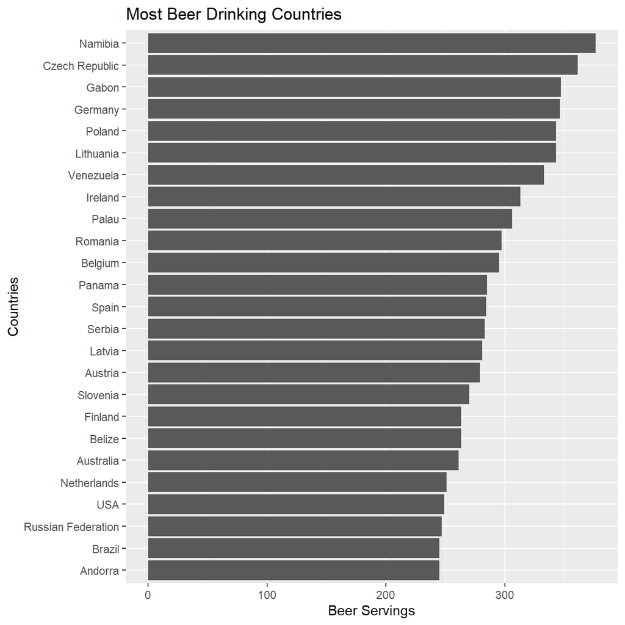

```r
drinks %>%
  slice_max(order_by = beer_servings, n=25) %>%
  ggplot(aes(x = beer_servings, y = fct_reorder(country, beer_servings))) +
  geom_col() +
  labs(
    title = "Most Beer Drinking Countries",
    x = "Beer Servings",
    y = "Countries"
  )
```

```r
  NULL
```

Make a plot that shows the top 25 wine consuming countries

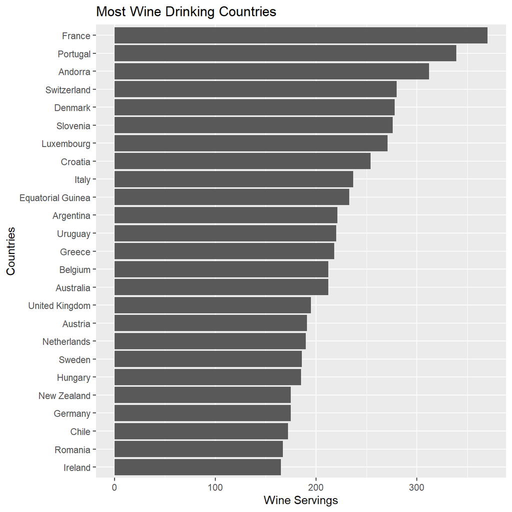

```r
drinks %>%
  slice_max(order_by = wine_servings, n=25) %>%
  ggplot(aes(x = wine_servings, y = fct_reorder(country, wine_servings))) +
  geom_col()+
  labs(
    title = "Most Wine Drinking Countries",
    x = "Wine Servings",
    y = "Countries"
  )
```

```r
  NULL
```

Finally, make a plot that shows the top 25 spirit consuming countries

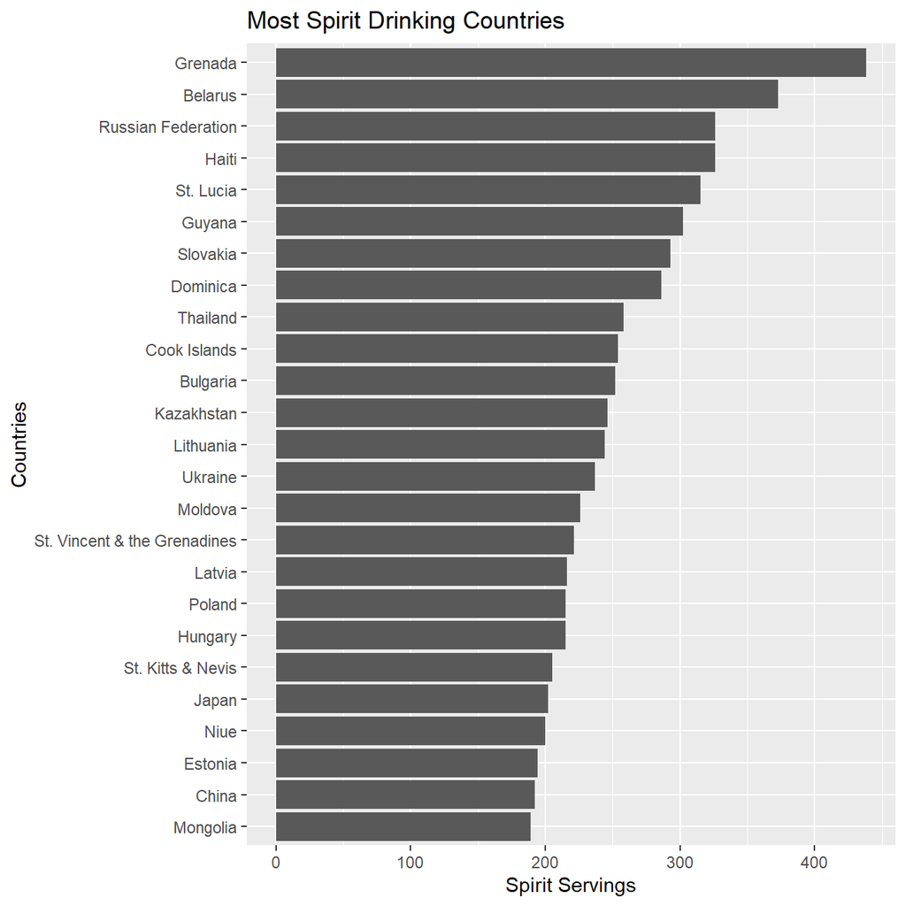

```r
# YOUR CODE GOES HERE
drinks %>%
  slice_max(order_by = spirit_servings, n=25) %>%
  ggplot(aes(x = spirit_servings, y = fct_reorder(country, spirit_servings))) +
  geom_col()+
  labs(
    title = "Most Spirit Drinking Countries",
    x = "Spirit Servings",
    y = "Countries"
  )
```

```r
  NULL
```

What can you infer from these plots? Don’t just explain what’s in the graph, but speculate or tell a short story (1-2 paragraphs max).

Wine seems to be consumed mostly in Europe while both beer and spirit has higher spread throughout the world. Also, while both wine and beer follow a continuous decrease from most drinking country to least drinking, spirit seems to drop heavily after the two top most drinking countries which are Grenada and Belarus. This mean that Grenada and Belarus drink much more spirit than other most spirit drinking countries.

# 2 Analysis of movies- IMDB dataset

```r
movies <- read_csv(here::here("data", "movies.csv"))
glimpse(movies)
```

```
## Rows: 2,961
## Columns: 11
## $ title               <chr> "Avatar", "Titanic", "Jurassic World", "The Avenge~
## $ genre               <chr> "Action", "Drama", "Action", "Action", "Action", "~
## $ director            <chr> "James Cameron", "James Cameron", "Colin Trevorrow~
## $ year                <dbl> 2009, 1997, 2015, 2012, 2008, 1999, 1977, 2015, 20~
## $ duration            <dbl> 178, 194, 124, 173, 152, 136, 125, 141, 164, 93, 1~
## $ gross               <dbl> 7.61e+08, 6.59e+08, 6.52e+08, 6.23e+08, 5.33e+08, ~
## $ budget              <dbl> 2.37e+08, 2.00e+08, 1.50e+08, 2.20e+08, 1.85e+08, ~
## $ cast_facebook_likes <dbl> 4834, 45223, 8458, 87697, 57802, 37723, 13485, 920~
## $ votes               <dbl> 886204, 793059, 418214, 995415, 1676169, 534658, 9~
## $ reviews             <dbl> 3777, 2843, 1934, 2425, 5312, 3917, 1752, 1752, 35~
## $ rating              <dbl> 7.9, 7.7, 7.0, 8.1, 9.0, 6.5, 8.7, 7.5, 8.5, 7.2, ~
```

Besides the obvious variables of `title`, `genre`, `director`, `year`, and `duration`, the rest of the variables are as follows:

- `gross` : The gross earnings in the US box office, not adjusted for inflation
- `budget`: The movie’s budget
- `cast_facebook_likes`: the number of facebook likes cast memebrs received
- `votes`: the number of people who voted for (or rated) the movie in IMDB
- `reviews`: the number of reviews for that movie
- `rating`: IMDB average rating
- Are there any missing values (NAs)? Are allis. entries distinct or are there duplicate entries?

```r
#This can easily be checked by base R. is.na() determines if there are any missing. If there is it returns true. Therefore if the sum is 0 it means there are no missing values.
sum(is.na(movies))
```

```
## [1] 0
```

```r
#Dublicated uses the same logic. If a movie with same name is used it will be returned as true. Summing them up will show the number of duplicates.
sum(duplicated(movies$title))
```

```
## [1] 54
```

```r
#Skim() function will serve as a double-check for both.
skim(movies)
```

Data summary

| Name | movies |
| --- | --- |
| Number of rows | 2961 |
| Number of columns | 11 |
| _______________________ |  |
| Column type frequency: |  |
| character | 3 |
| numeric | 8 |
| ________________________ |  |
| Group variables | None |

**Variable type: character**

| skim_variable | n_missing | complete_rate | min | max | empty | n_unique | whitespace |
| --- | --- | --- | --- | --- | --- | --- | --- |
| title | 0 | 1 | 1 | 83 | 0 | 2907 | 0 |
| genre | 0 | 1 | 5 | 11 | 0 | 17 | 0 |
| director | 0 | 1 | 3 | 32 | 0 | 1366 | 0 |

**Variable type: numeric**

| skim_variable | n_missing | complete_rate | mean | sd | p0 | p25 | p50 | p75 | p100 | hist |
| --- | --- | --- | --- | --- | --- | --- | --- | --- | --- | --- |
| year | 0 | 1 | 2.00e+03 | 9.95e+00 | 1920.0 | 2.00e+03 | 2.00e+03 | 2.01e+03 | 2.02e+03 | ▁▁▁▂▇ |
| duration | 0 | 1 | 1.10e+02 | 2.22e+01 | 37.0 | 9.50e+01 | 1.06e+02 | 1.19e+02 | 3.30e+02 | ▃▇▁▁▁ |
| gross | 0 | 1 | 5.81e+07 | 7.25e+07 | 703.0 | 1.23e+07 | 3.47e+07 | 7.56e+07 | 7.61e+08 | ▇▁▁▁▁ |
| budget | 0 | 1 | 4.06e+07 | 4.37e+07 | 218.0 | 1.10e+07 | 2.60e+07 | 5.50e+07 | 3.00e+08 | ▇▂▁▁▁ |
| cast_facebook_likes | 0 | 1 | 1.24e+04 | 2.05e+04 | 0.0 | 2.24e+03 | 4.60e+03 | 1.69e+04 | 6.57e+05 | ▇▁▁▁▁ |
| votes | 0 | 1 | 1.09e+05 | 1.58e+05 | 5.0 | 1.99e+04 | 5.57e+04 | 1.33e+05 | 1.69e+06 | ▇▁▁▁▁ |
| reviews | 0 | 1 | 5.03e+02 | 4.94e+02 | 2.0 | 1.99e+02 | 3.64e+02 | 6.31e+02 | 5.31e+03 | ▇▁▁▁▁ |
| rating | 0 | 1 | 6.39e+00 | 1.05e+00 | 1.6 | 5.80e+00 | 6.50e+00 | 7.10e+00 | 9.30e+00 | ▁▁▆▇▁ |

- Produce a table with the count of movies by genre, ranked in descending order

```r
movies %>%
  group_by(genre) %>%
  count(sort=TRUE)
```

```
## # A tibble: 17 x 2
## # Groups:   genre [17]
##    genre           n
##    <chr>       <int>
##  1 Comedy        848
##  2 Action        738
##  3 Drama         498
##  4 Adventure     288
##  5 Crime         202
##  6 Biography     135
##  7 Horror        131
##  8 Animation      35
##  9 Fantasy        28
## 10 Documentary    25
## 11 Mystery        16
## 12 Sci-Fi          7
## 13 Family          3
## 14 Musical         2
## 15 Romance         2
## 16 Western         2
## 17 Thriller        1
```

- Produce a table with the average gross earning and budget (`gross` and `budget`) by genre. Calculate a variable `return_on_budget` which shows how many $ did a movie make at the box office for each $ of its budget. Ranked genres by this `return_on_budget` in descending order

```r
movies %>%
  group_by(genre) %>%
  summarise(average_gross=mean(gross),average_budget=mean(budget),return_on_budget=average_gross/average_budget) %>%
  arrange(desc(return_on_budget))
```

```
## # A tibble: 17 x 4
##    genre       average_gross average_budget return_on_budget
##    <chr>               <dbl>          <dbl>            <dbl>
##  1 Musical         92084000        3189500          28.9
##  2 Family         149160478.      14833333.         10.1
##  3 Western         20821884        3465000           6.01
##  4 Documentary     17353973.       5887852.          2.95
##  5 Horror          37713738.      13504916.          2.79
##  6 Fantasy         42408841.      17582143.          2.41
##  7 Comedy          42630552.      24446319.          1.74
##  8 Mystery         67533021.      39218750           1.72
##  9 Animation       98433792.      61701429.          1.60
## 10 Biography       45201805.      28543696.          1.58
## 11 Adventure       95794257.      66290069.          1.45
## 12 Drama           37465371.      26242933.          1.43
## 13 Crime           37502397.      26596169.          1.41
## 14 Romance         31264848.      25107500           1.25
## 15 Action          86583860.      71354888.          1.21
## 16 Sci-Fi          29788371.      27607143.          1.08
## 17 Thriller            2468         300000           0.00823
```

- Produce a table that shows the top 15 directors who have created the highest gross revenue in the box office. Don’t just show the total gross amount, but also the mean, median, and standard deviation per director.

```r
movies %>%
  group_by(director) %>%
  summarise(total_gross= sum(gross),mean_gross=mean(gross),median_gross=median(gross),sd_gross=sd(gross)) %>%
  slice_max(order_by = total_gross, n=15)
```

```
## # A tibble: 15 x 5
##    director          total_gross mean_gross median_gross   sd_gross
##    <chr>                   <dbl>      <dbl>        <dbl>      <dbl>
##  1 Steven Spielberg   4014061704 174524422.   164435221  101421051.
##  2 Michael Bay        2231242537 171634041.   138396624  127161579.
##  3 Tim Burton         2071275480 129454718.    76519172  108726924.
##  4 Sam Raimi          2014600898 201460090.   234903076  162126632.
##  5 James Cameron      1909725910 318287652.   175562880. 309171337.
##  6 Christopher Nolan  1813227576 226653447    196667606. 187224133.
##  7 George Lucas       1741418480 348283696    380262555  146193880.
##  8 Robert Zemeckis    1619309108 124562239.   100853835   91300279.
##  9 Clint Eastwood     1378321100  72543216.    46700000   75487408.
## 10 Francis Lawrence   1358501971 271700394.   281666058  135437020.
## 11 Ron Howard         1335988092 111332341    101587923   81933761.
## 12 Gore Verbinski     1329600995 189942999.   123207194  154473822.
## 13 Andrew Adamson     1137446920 284361730    279680930. 120895765.
## 14 Shawn Levy         1129750988 102704635.    85463309   65484773.
## 15 Ridley Scott       1128857598  80632686.    47775715   68812285.
```

- Finally, ratings. Produce a table that describes how ratings are distributed by genre. We don’t want just the mean, but also, min, max, median, SD and some kind of a histogram or density graph that visually shows how ratings are distributed.

```r
movies %>%
  group_by(genre) %>%
  summarise(mean_rating=mean(rating),median_rating=median(rating),sd_rating=sd(rating))
```

```
## # A tibble: 17 x 4
##    genre       mean_rating median_rating sd_rating
##    <chr>             <dbl>         <dbl>     <dbl>
##  1 Action             6.23          6.3      1.03
##  2 Adventure          6.51          6.6      1.09
##  3 Animation          6.65          6.9      0.968
##  4 Biography          7.11          7.2      0.760
##  5 Comedy             6.11          6.2      1.02
##  6 Crime              6.92          6.9      0.849
##  7 Documentary        6.66          7.4      1.77
##  8 Drama              6.73          6.8      0.917
##  9 Family             6.5           5.9      1.22
## 10 Fantasy            6.15          6.45     0.959
## 11 Horror             5.83          5.9      1.01
## 12 Musical            6.75          6.75     0.636
## 13 Mystery            6.86          6.9      0.882
## 14 Romance            6.65          6.65     0.636
## 15 Sci-Fi             6.66          6.4      1.09
## 16 Thriller           4.8           4.8     NA
## 17 Western            5.7           5.7      2.26
```

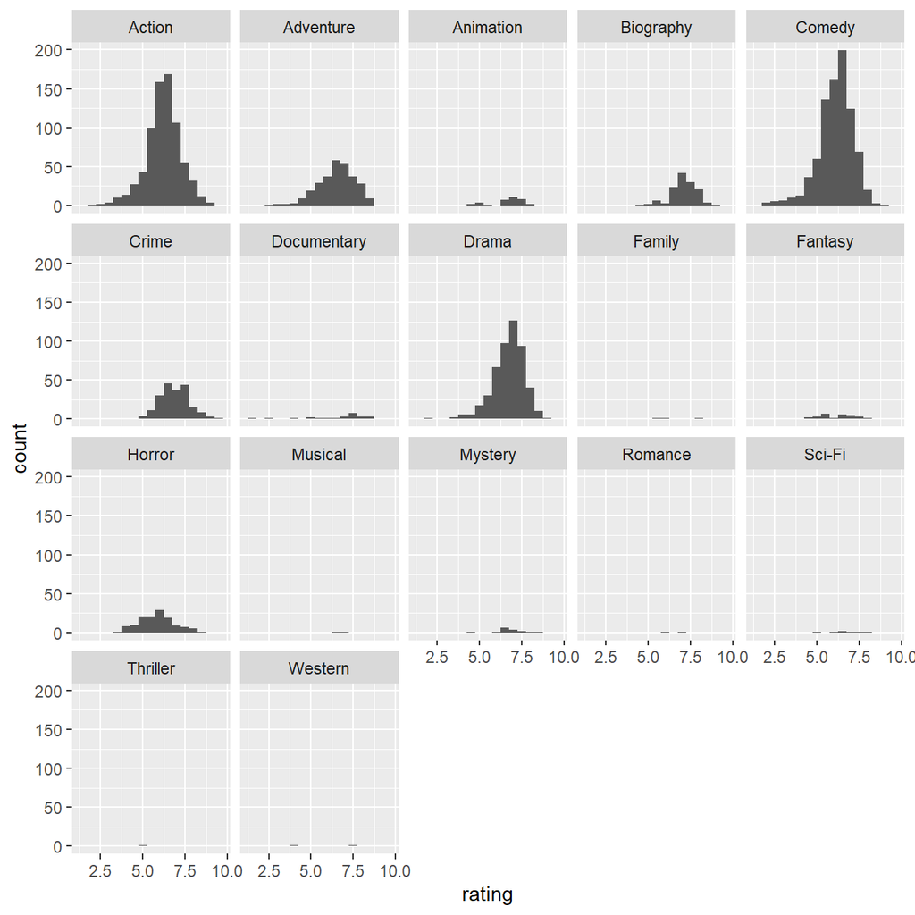

```r
movies %>%
  ggplot(aes(x=rating)) +
  geom_histogram(binwidth = 0.5)+
  facet_wrap(~genre)
```

- Examine the relationship between `gross` and `cast_facebook_likes`. Produce a scatterplot and write one sentence discussing whether the number of facebook likes that the cast has received is likely to be a good predictor of how much money a movie will make at the box office. What variable are you going to map to the Y- and X- axes?

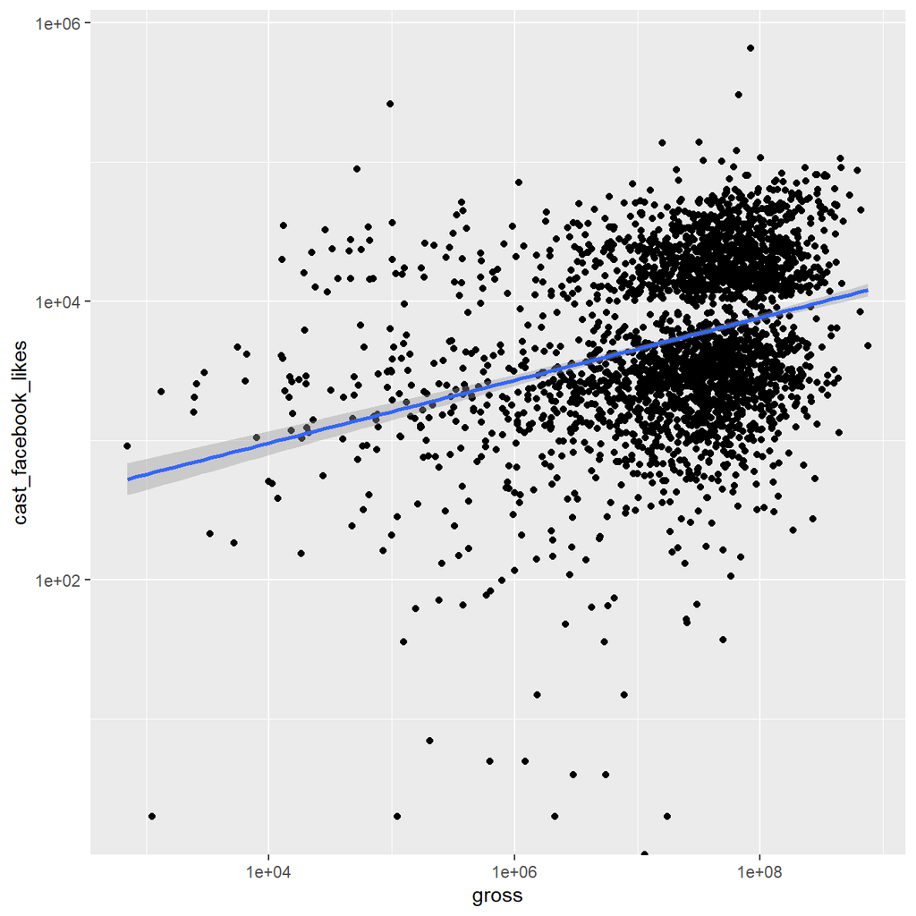

```r
movies %>%
  ggplot(aes(x=gross,y=cast_facebook_likes)) +
  geom_point()+
  scale_x_log10()+
  scale_y_log10()+
  geom_smooth(method="lm")
```

```r
cor(movies$gross,movies$cast_facebook_likes)
```

```
## [1] 0.213
```

There is a positive correlation between the gross and facebook lines but as it can be seen from both the scatter plot and the correlation figure it is not strong. Therefore, ideally we shouldn’t use this as a single metric to predict.

- Examine the relationship between `gross` and `budget`. Produce a scatterplot and write one sentence discussing whether budget is likely to be a good predictor of how much money a movie will make at the box office.

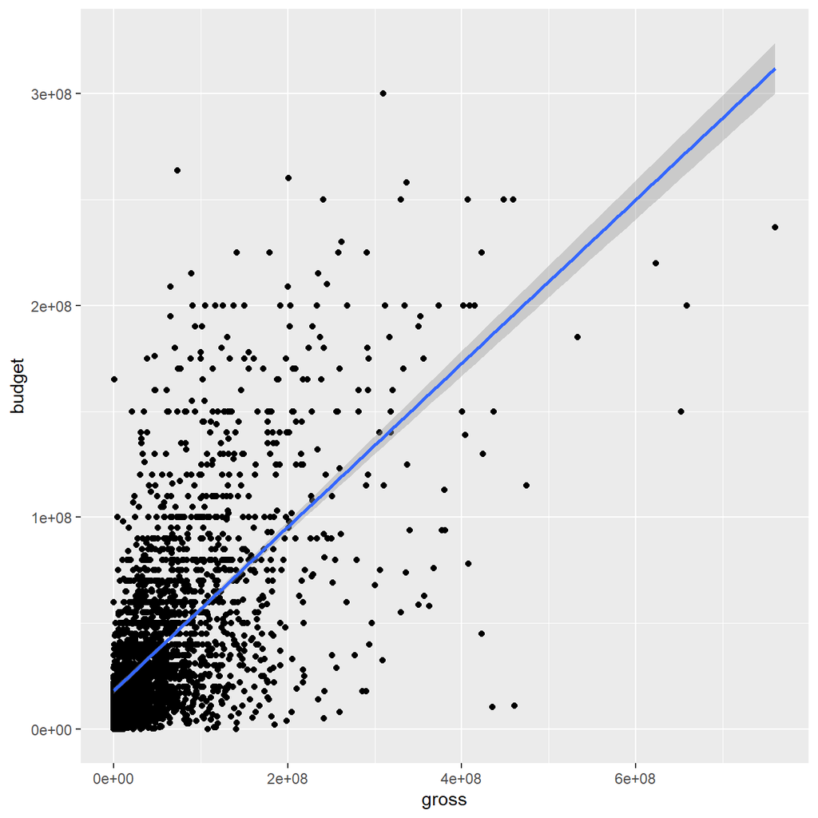

```r
movies %>%
  ggplot(aes(x=gross,y=budget)) +
  geom_point()+
  geom_smooth(method="lm")
```

```r
cor(movies$gross,movies$budget)
```

```
## [1] 0.641
```

There is a strong correlation of 0.64 between budget and gross. The relationship is also apperant in the scatter plot. That means more budget a movie has more gross it will achive.

- Examine the relationship between `gross` and `rating`. Produce a scatterplot, faceted by `genre` and discuss whether IMDB ratings are likely to be a good predictor of how much money a movie will make at the box office. Is there anything strange in this dataset?

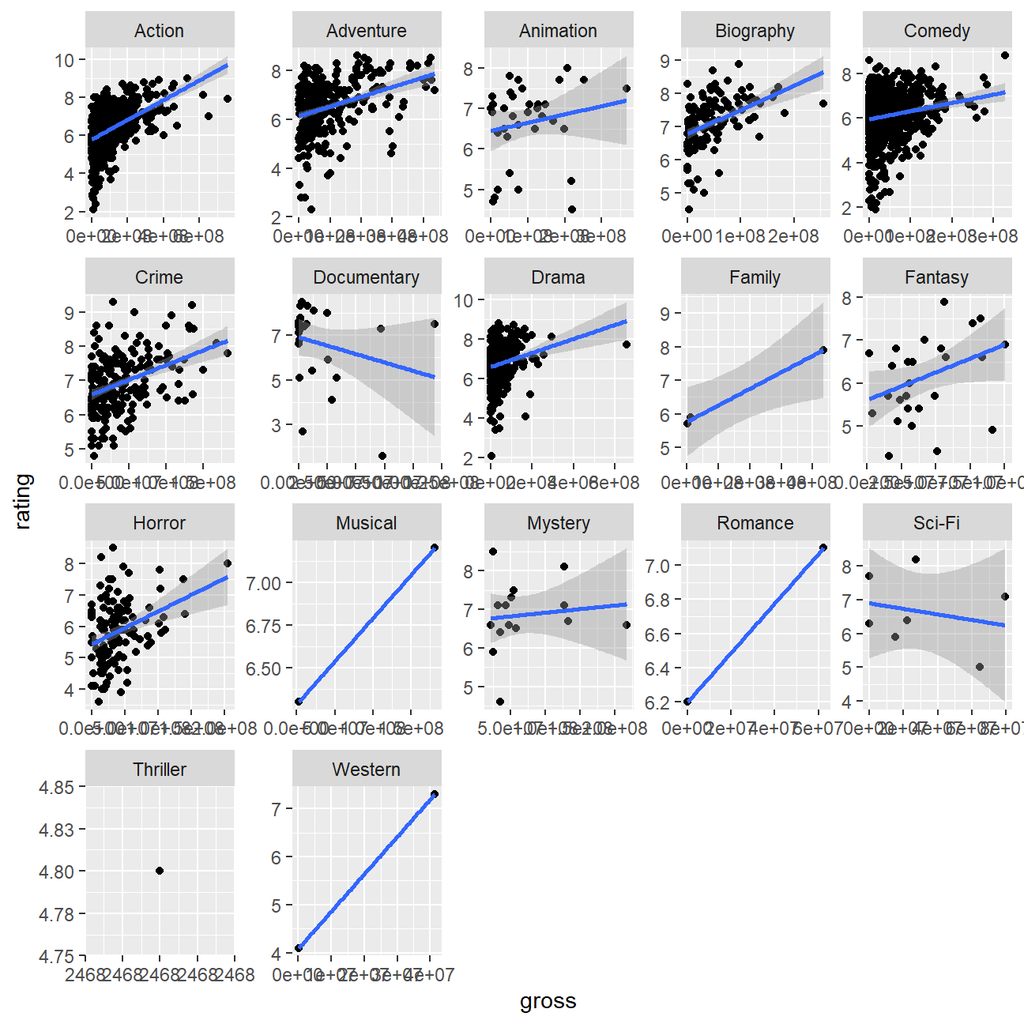

```r
movies %>%
  ggplot(aes(x=gross,y=rating)) +
  geom_point()+
  geom_smooth(method="lm")+
  facet_wrap(~genre,scale="free")
```

IMDB ratings are not a good predictor of the gross for most of the genres. There are strange findings as in some genres such as sci-fi and documentary, the ratings and the gross are negatively correlated. Also for some genres such as thriller and musical there aren’t enough data points to determine a regression.

# 3 Returns of financial stocks

```r
nyse <- read_csv(here::here("data","nyse.csv"))
```

Based on this dataset, create a table and a bar plot that shows the number of companies per sector, in descending order

```r
nyse %>%
  group_by(sector) %>%
  summarise(number_of_companies = count(sector)) %>%
  arrange(desc(number_of_companies))
```

```
## # A tibble: 12 x 2
##    sector                number_of_companies
##    <chr>                               <int>
##  1 Finance                                97
##  2 Consumer Services                      79
##  3 Public Utilities                       60
##  4 Capital Goods                          45
##  5 Health Care                            45
##  6 Energy                                 42
##  7 Technology                             40
##  8 Basic Industries                       39
##  9 Consumer Non-Durables                  31
## 10 Miscellaneous                          12
## 11 Transportation                         10
## 12 Consumer Durables                       8
```

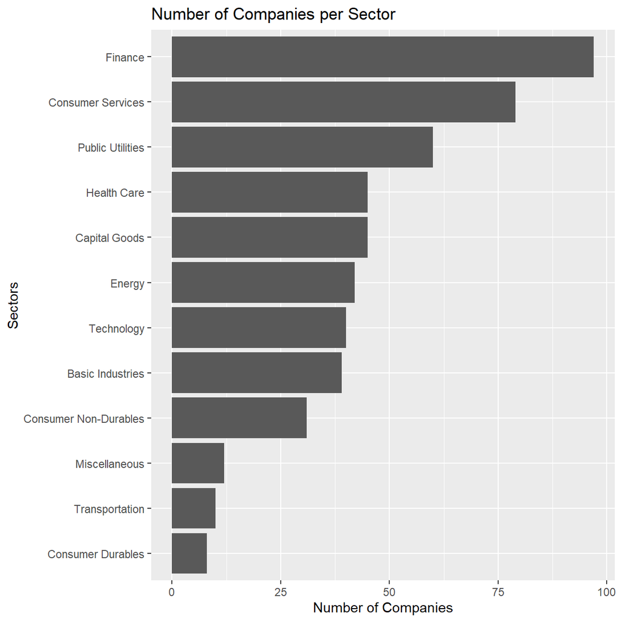

```r
nyse %>%
  group_by(sector) %>%
  summarise(number_of_companies = count(sector)) %>%
  ggplot(aes(y = fct_reorder(sector,number_of_companies), x =number_of_companies )) +
  geom_col() +
  labs(
    title = "Number of Companies per Sector",
    x = "Number of Companies",
    y = "Sectors"
  )
```

```r
  NULL
```

```r
djia_url <- "https://en.wikipedia.org/wiki/Dow_Jones_Industrial_Average"


#get tables that exist on URL
tables <- djia_url %>%
  read_html() %>%
  html_nodes(css="table")


# parse HTML tables into a dataframe called djia.
# Use purr::map() to create a list of all tables in URL
djia <- map(tables, . %>%
               html_table(fill=TRUE)%>%
               clean_names())


# constituents
table1 <- djia[[2]] %>% # the second table on the page contains the ticker symbols
  mutate(date_added = ymd(date_added),

         # if a stock is listed on NYSE, its symbol is, e.g., NYSE: MMM
         # We will get prices from yahoo finance which requires just the ticker

         # if symbol contains "NYSE*", the * being a wildcard
         # then we jsut drop the first 6 characters in that string
         ticker = ifelse(str_detect(symbol, "NYSE*"),
                          str_sub(symbol,7,11),
                          symbol)
         )

# we need a vector of strings with just the 30 tickers + SPY
tickers <- table1 %>%
  select(ticker) %>%
  pull() %>% # pull() gets them as a sting of characters
  c("SPY") # and lets us add SPY, the SP500 ETF
```

```r
# Notice the cache=TRUE argument in the chunk options. Because getting data is time consuming, # cache=TRUE means that once it downloads data, the chunk will not run again next time you knit your Rmd

myStocks <- tickers %>%
  tq_get(get  = "stock.prices",
         from = "2000-01-01",
         to   = Sys.Date()) %>% # Sys.Date() returns today's price
  group_by(symbol)

glimpse(myStocks) # examine the structure of the resulting data frame
```

```
## Rows: 161,491
## Columns: 8
## Groups: symbol [31]
## $ symbol   <chr> "MMM", "MMM", "MMM", "MMM", "MMM", "MMM", "MMM", "MMM", "MMM"~
## $ date     <date> 2000-01-03, 2000-01-04, 2000-01-05, 2000-01-06, 2000-01-07, ~
## $ open     <dbl> 48.0, 46.4, 45.6, 47.2, 50.6, 50.2, 50.4, 51.0, 50.7, 50.4, 4~
## $ high     <dbl> 48.2, 47.4, 48.1, 51.2, 51.9, 51.8, 51.2, 51.8, 50.9, 50.5, 4~
## $ low      <dbl> 47.0, 45.3, 45.6, 47.2, 50.0, 50.0, 50.2, 50.4, 50.2, 49.5, 4~
## $ close    <dbl> 47.2, 45.3, 46.6, 50.4, 51.4, 51.1, 50.2, 50.4, 50.4, 49.7, 4~
## $ volume   <dbl> 2173400, 2713800, 3699400, 5975800, 4101200, 3863800, 2357600~
## $ adjusted <dbl> 27.2, 26.1, 26.9, 29.0, 29.6, 29.4, 28.9, 29.0, 29.0, 28.6, 2~
```

```r
#calculate daily returns
myStocks_returns_daily <- myStocks %>%
  tq_transmute(select     = adjusted,
               mutate_fun = periodReturn,
               period     = "daily",
               type       = "log",
               col_rename = "daily_returns",
               cols = c(nested.col))

#calculate monthly  returns
myStocks_returns_monthly <- myStocks %>%
  tq_transmute(select     = adjusted,
               mutate_fun = periodReturn,
               period     = "monthly",
               type       = "arithmetic",
               col_rename = "monthly_returns",
               cols = c(nested.col))

#calculate yearly returns
myStocks_returns_annual <- myStocks %>%
  group_by(symbol) %>%
  tq_transmute(select     = adjusted,
               mutate_fun = periodReturn,
               period     = "yearly",
               type       = "arithmetic",
               col_rename = "yearly_returns",
               cols = c(nested.col))
```

Create a table where you summarise monthly returns for each of the stocks and `SPY`; min, max, median, mean, SD.

```r
myStocks_returns_monthly %>%
  group_by(symbol) %>%
  summarise( min_return= min(monthly_returns),max_return= max(monthly_returns), median_return = median(monthly_returns),average_return = mean(monthly_returns),sd_return=sd(monthly_returns) ) %>%
  arrange(sd_return)
```

```
## # A tibble: 31 x 6
##    symbol min_return max_return median_return average_return sd_return
##    <chr>       <dbl>      <dbl>         <dbl>          <dbl>     <dbl>
##  1 SPY        -0.165      0.127       0.0118         0.00678    0.0432
##  2 JNJ        -0.160      0.174       0.00890        0.00814    0.0474
##  3 KO         -0.167      0.142       0.00938        0.00604    0.0501
##  4 PG         -0.354      0.119       0.00906        0.00737    0.0507
##  5 WMT        -0.181      0.160       0.00654        0.00591    0.0542
##  6 MCD        -0.257      0.183       0.0145         0.0107     0.0561
##  7 MMM        -0.150      0.207       0.0115         0.00894    0.0577
##  8 VZ         -0.210      0.393       0.00341        0.00575    0.0638
##  9 CVX        -0.224      0.273       0.0101         0.00852    0.0653
## 10 V          -0.196      0.338       0.0255         0.0200     0.0661
## # ... with 21 more rows
```

Plot a density plot, using `geom_density()`, for each of the stocks

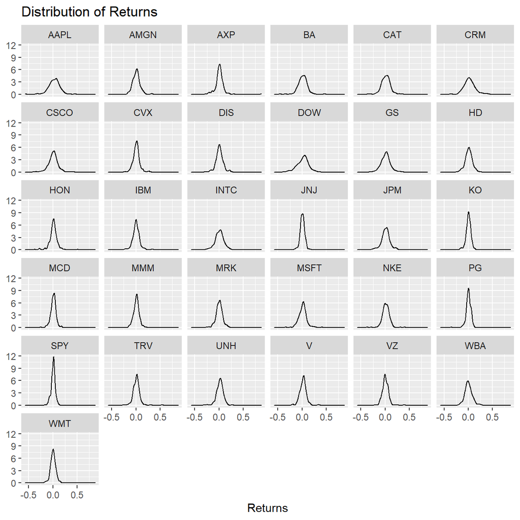

```r
myStocks_returns_monthly %>%
  ggplot(aes(x=monthly_returns)) +
  labs(
    title = "Distribution of Returns",
    x = "Returns",
    y = NULL
  )+
  geom_density()+
  facet_wrap(~symbol)
```

What can you infer from this plot? Which stock is the riskiest? The least risky?

To assess the riskiness of a stock, we need to look at the spread of returns in the density plot. If the spread is high, that means both the upside and the downside risk is high. Therefore, the plots with high kurtosis will be less risky, the plots with low kurtosis will be risky.

Riskiest Stock: AAPL Least Risky Stock: SPY

Finally, make a plot that shows the expected monthly return (mean) of a stock on the Y axis and the risk (standard deviation) in the X-axis. Please use `ggrepel::geom_text_repel()` to label each stock

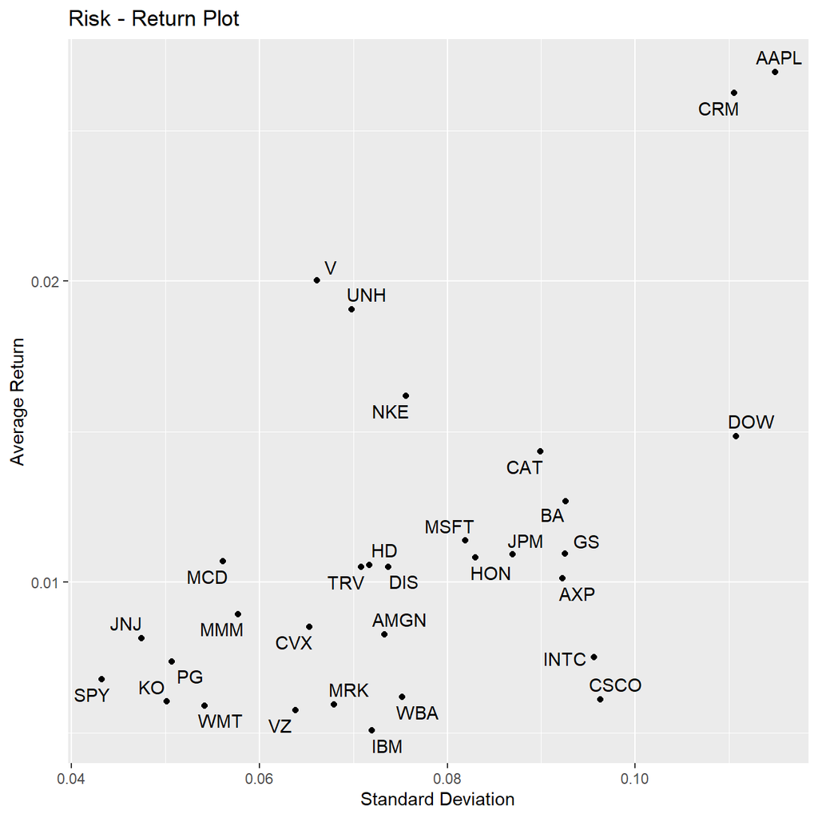

```r
myStocks_returns_monthly %>%
  summarise(average_return = mean(monthly_returns),sd_return=sd(monthly_returns) ) %>%
  ggplot(aes(x =sd_return,y=average_return,label = symbol))+
  geom_point()+
  ggrepel::geom_text_repel()+
  labs(
    title = "Risk - Return Plot",
    x = "Standard Deviation",
    y = "Average Return"
  )
```

What can you infer from this plot? Are there any stocks which, while being riskier, do not have a higher expected return?

From the plot one can understand the risk-return profile of a stock. Higher the standard deviation, more volatile the stock so an investor should expect more earnings from this stock. However, there are some stocks that while risky do not offer high expected returns. CSCO is an example of this. While it’s the fourth most volatile stock, its expected return is way below the average. INTC and AXP are also examples of this.

# 4 Is inflation transitory?

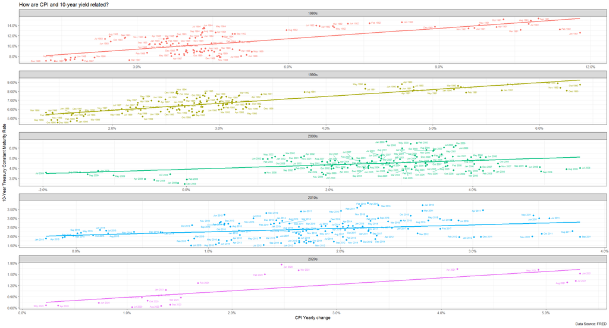

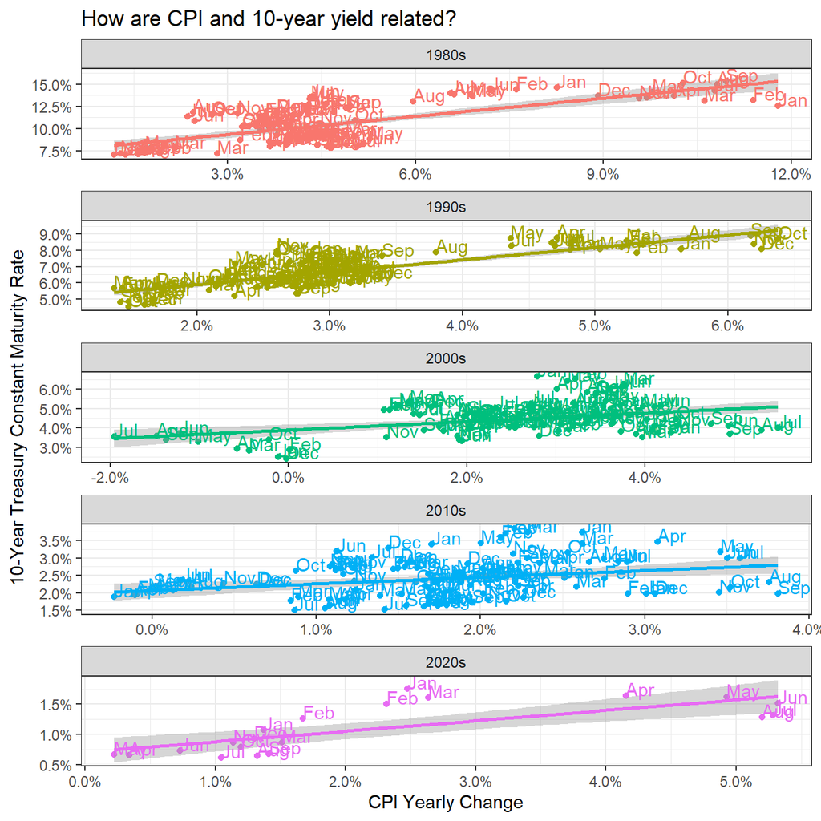

```r
cpi  <-   tq_get("CPIAUCSL", get = "economic.data",
                       from = "1980-01-01") %>%
  rename(cpi = symbol, rate = price) %>% # Since data from FRED is labelled as 'symbol' and 'price', we rename them to what they really are, e.g., cpi and rate

  # Yearly change in CPI is calculated by dividing current month by same month a year (or 12 months) earlier, minus 1
  mutate(cpi_yoy_change = rate/lag(rate, 12) - 1)

ten_year_monthly  <-   tq_get("GS10", get = "economic.data",
                       from = "1980-01-01") %>%
  rename(ten_year = symbol,
         yield = price) %>%
  mutate(yield = yield / 100)
# Since the original data is not given as, e.g., 0.05, but rather 5, for five percent, we divide it by 100

# We put together the two data frames using left_join()

mydata <-
  cpi %>%
  left_join(ten_year_monthly, by="date") %>%
  mutate(
    year = year(date), # using lubridate::year() to generate a new column with just the year
    month = month(date, label = TRUE),
    decade=case_when(
      year %in% 1980:1989 ~ "1980s",
      year %in% 1990:1999 ~ "1990s",
      year %in% 2000:2009 ~ "2000s",
      year %in% 2010:2019 ~ "2010s",
      TRUE ~ "2020s"
      )
  )

# Now we plot the data as scatter points

ggplot(
  data = mydata,
  mapping = aes(
    x = cpi_yoy_change,
    y = yield, color = decade)) +
  geom_point() +
  labs(title = "How are CPI and 10-year yield related?",
       x = "CPI Yearly Change",
       y = "10-Year Treasury Constant Maturity Rate")+
  scale_y_continuous(labels = scales::percent_format(accuracy = 0.1)) +
  scale_x_continuous(labels = scales::percent_format(accuracy = 0.1)) +
  facet_wrap(~decade, nrow=5, scales = "free") +
  theme_bw()+
  geom_smooth(method = lm)+
  geom_text(aes(label=month),hjust=0, vjust=0) +
  theme(legend.position = "none")
```

```r
  NULL
```

It can be seen from the graph that there has been an increase of Consumer Price Index recently. The recent study by the Bank for International Settlements claiming that the Current Inflation Spike Is Just Transitory states that the surge in inflation was confined to few volatile sectors, and this claim seems to be proved by the trend of core CPI data, which was up in August only by 0.1%. However, as the impact of Covid-19 pandemic slowly fades, loads of large industries are recovering. For instance, we might see not only travel and airline-ticket prices recover, which would contribute to the inflation, but also smaller industries such as suits having large market moves. Therefore, it is believed that in the short term, inflation might calm down as everything returns to normal, but in a much slower pace than the authorities believe. Also, in the long term, the pandemic might have lasting impact on the markets and economies.

From the graph we can tell that there is a positive correlation between CPI and the 10-year yields. That is because inflation diminishes the purchasing power of bonds’ future cash flows. Therefore, the higher the inflation, the higher the yields, as investors demand higher yield to compensate for the inflation risk.

# 5 Challenge 1: Replicating a chart

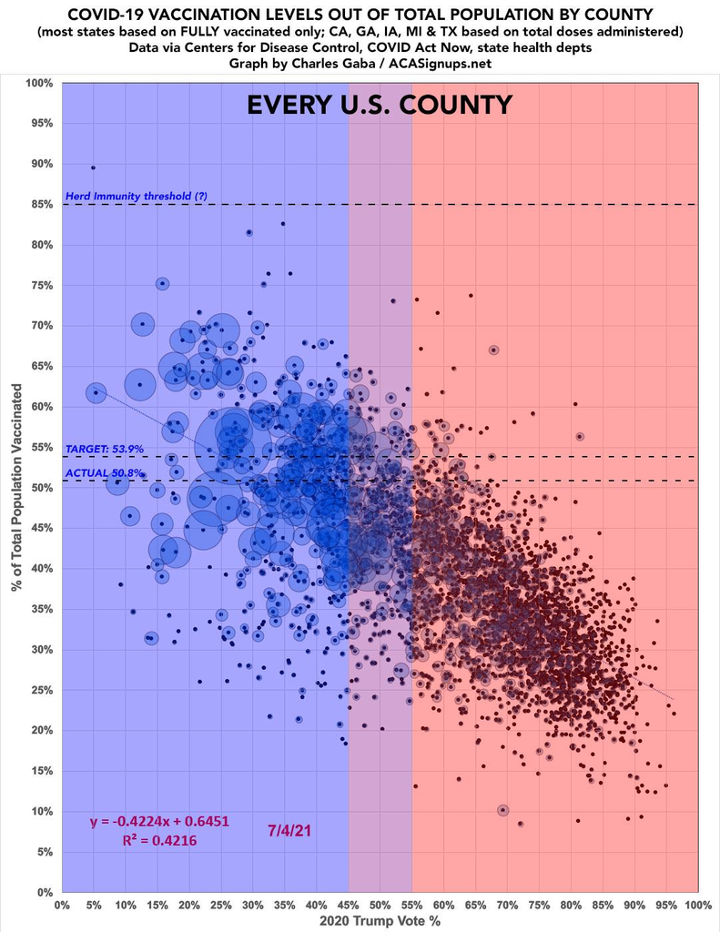

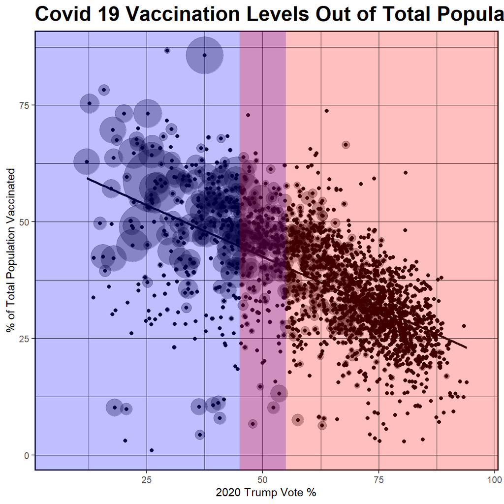

```r
# Download CDC vaccination by county
cdc_url <- "https://data.cdc.gov/api/views/8xkx-amqh/rows.csv?accessType=DOWNLOAD"
vaccinations <- vroom(cdc_url) %>%
  janitor::clean_names() %>%
  filter(fips != "UNK") # remove counties that have an unknown (UNK) FIPS code

# Download County Presidential Election Returns
# https://dataverse.harvard.edu/dataset.xhtml?persistentId=doi:10.7910/DVN/VOQCHQ


election2020_results <- vroom(here::here("data","countypres_2000-2020.csv" )) %>%
  janitor::clean_names() %>%

  # just keep the results for the 2020 election
  filter(year == "2020") %>%

  # change original name county_fips to fips, to be consistent with the other two files
  rename (fips = county_fips)

# Download county population data
population_url <- "https://www.ers.usda.gov/webdocs/DataFiles/48747/PopulationEstimates.csv?v=2232"
population <- vroom(population_url) %>%
  janitor::clean_names() %>%

  # select the latest data, namely 2019
  select(fips = fip_stxt, pop_estimate_2019) %>%

  # pad FIPS codes with leading zeros, so they are always made up of 5 characters
  mutate(fips = stringi::stri_pad_left(fips, width=5, pad = "0"))

#Filtering out irrelevant data from election results
trump2020_results <- election2020_results %>%
  filter (candidate == 'DONALD J TRUMP', mode == 'TOTAL') %>%
  select(fips, candidatevotes, totalvotes) %>% #we only need these three datasets
  mutate (percentage_trump=candidatevotes/totalvotes*100) %>% #creating new column for trump votes %
  select (-candidatevotes, -totalvotes) #removing these columns as we don't need them anymore

#Filtering out irrelevant data from Vaccinations
vaccinations_cleaned <- vaccinations %>%
  filter (date == '07/04/2021') %>% #Filtering for July 4, 2021
  mutate (pct_vaccinated=case_when(recip_state %in% c ('CA', 'GA', 'IA', 'MI', 'TX') ~ administered_dose1_pop_pct,
      T ~ series_complete_pop_pct)) %>%
  #Using administered doses % data instead of complete pop for exemptions - using professor's help on Slack
  select(fips, pct_vaccinated) %>% #Just keep necessary columns
  filter (pct_vaccinated > 0.0) #Filter out pct_vaccinated = 0%

#Joining election result data and vaccination data
merged_data <- trump2020_results %>%
  left_join (population, by='fips') %>%
  left_join (vaccinations_cleaned, by='fips')

#Creating the graph
ggplot(merged_data, aes(x=percentage_trump, y=pct_vaccinated)) +
  geom_point(size=1.5) + #to create a point
  geom_point(alpha=0.3, aes(size = pop_estimate_2019), colour='black') + #to create a bubble with opacity 0.3
  scale_size(range = c(.1, 40), name="Population") + #to define bubble size
  geom_smooth(method="lm", se=F, color="black") + #to add a line
  ggtitle("Covid 19 Vaccination Levels Out of Total Population by County") +
  xlab("2020 Trump Vote %") +
  ylab("% of Total Population Vaccinated")+
  annotate("rect", xmin=-Inf, xmax=55, ymin=-Inf, ymax=Inf, alpha=0.25, fill="blue") +
  annotate("rect", xmin=45, xmax=Inf, ymin=-Inf, ymax=Inf, alpha=0.25, fill="red") +
  theme(panel.background = element_rect(fill = "#ffffff", colour = "#000000", size = 1, linetype = "solid"),
  panel.grid.major = element_line(size = 0.1, linetype = 'solid',
                                colour = "black"),
  panel.grid.minor = element_line(size = 0.1, linetype = 'solid',
                                colour = "black")) +
  theme(plot.title = element_text(size = 20, face = "bold"))+
  theme(legend.position = "none")
```

# 6 Challenge 2: Opinion polls for the 2021 German elections

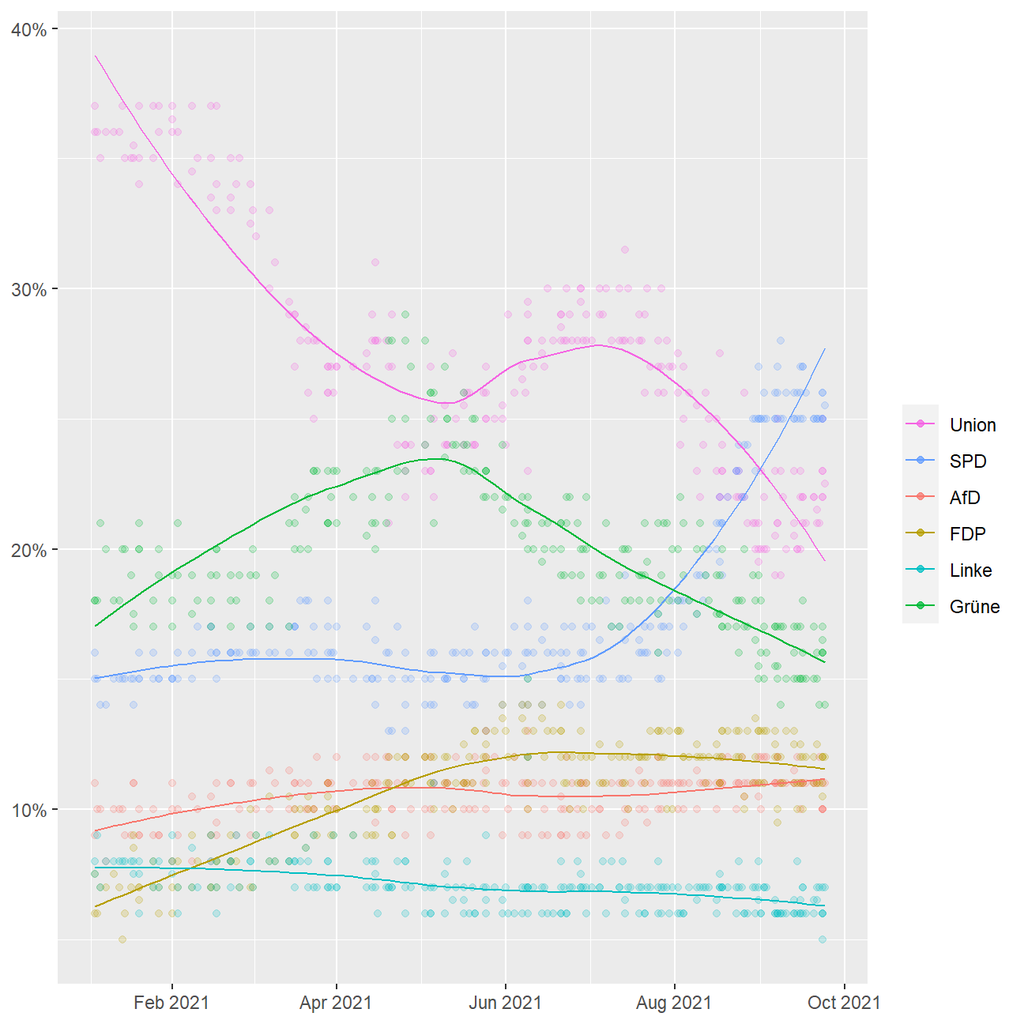

```r
url <- "https://en.wikipedia.org/wiki/Opinion_polling_for_the_2021_German_federal_election"

# similar graphs and analyses can be found at
# https://www.theguardian.com/world/2021/jun/21/german-election-poll-tracker-who-will-be-the-next-chancellor
# https://www.economist.com/graphic-detail/who-will-succeed-angela-merkel


# get tables that exist on wikipedia page
tables <- url %>%
  read_html() %>%
  html_nodes(css="table")


# parse HTML tables into a dataframe called polls
# Use purr::map() to create a list of all tables in URL
polls <- map(tables, . %>%
             html_table(fill=TRUE)%>%
             janitor::clean_names())


# list of opinion polls
german_election_polls <- polls[[1]] %>% # the first table on the page contains the list of all opinions polls
  slice(2:(n()-1)) %>%  # drop the first row, as it contains again the variable names and last row that contains 2017 results
  mutate(
         # polls are shown to run from-to, e.g. 9-13 Aug 2021. We keep the last date, 13 Aug here, as the poll date
         # and we extract it by picking the last 11 characters from that field
         end_date = str_sub(fieldwork_date, -11),

         # end_date is still a string, so we convert it into a date object using lubridate::dmy()
         end_date = dmy(end_date),

         # we also get the month and week number from the date, if we want to do analysis by month- week, etc.
         month = month(end_date),
         week = isoweek(end_date)
         )


  ggplot(data = german_election_polls) +

    geom_point(aes(x=end_date, y=union, col="Union"), alpha=2/10) +
    geom_point(aes(x=end_date, y=spd, col='SPD'), alpha=2/10) +
    geom_point(aes(x=end_date, y=af_d, col='AfD'), alpha=2/10) +
    geom_point(aes(x=end_date, y=fdp,col='FDP'), alpha=2/10) +
    geom_point(aes(x=end_date, y=linke,col='Linke'), alpha=2/10) +
    geom_point(aes(x=end_date, y=grune,col='Grüne'), alpha=2/10) +

    geom_smooth(aes(x=end_date, y=union, col="Union"), size=0.5,se=FALSE) +
    geom_smooth(aes(x=end_date, y=spd, col='SPD'), size=0.5, se=FALSE) +
    geom_smooth(aes(x=end_date, y=af_d, col='AfD'), size=0.5,  se=FALSE) +
    geom_smooth(aes(x=end_date, y=fdp, col='FDP'),  size=0.5, se=FALSE) +
    geom_smooth(aes(x=end_date, y=linke, col='Linke'),  size=0.5,se=FALSE) +
    geom_smooth(aes(x=end_date, y=grune, col='Grüne'),  size=0.5,se=FALSE) +

  scale_y_continuous(labels = function(x) paste0(x, "%")) + #y axes in percentages
  scale_x_date(breaks = "2 months",date_labels="%b %Y") + #format the dates on x axes+
  scale_color_discrete(breaks= c("Union", "SPD", "AfD","FDP","Linke","Grüne"))+ #Reorder items in legend
  labs(title=NULL,x=NULL, y= NULL, colour="" ) #deleting axes and legend labels
```

On the Wikipedia graph, there is a reversal of polls results between the Union party and the SPD party significant enough to reconsider Union’s party ability to win the elections. The previous code allows to zoom in on the recent trend inversion and look more closely at the dynamics that have occurred in the past months. What we can clearly see is an increase in the dispersion of the votes. Although the trend lines show a clear positive trend for the SPD party over the last 2 months, the points suggest that a win from the SPD is not even close to certain. As always when election date is approaching, the uncertainty increases and polls reflect the unpredictability.

# 7 Details

- Who did you collaborate with: Study Group B12. Yaxin Lyu 3789669, Mengtian Li 3756951, Jay Bansal 3614503, Jiacheng Zhu 3750422, Chloe Baubier 3729145
- Approximately how much time did you spend on this problem set: ~4 hours per person
- What, if anything, gave you the most trouble: Finding small errors( “%>% or ,” ) in big chunks of code

> As a true test to yourself, do you understand the code you submitted and are you able to explain it to someone else?

Yes